# A Visual and Statistical Analysis of 30,000 Spotify Songs

STAT 202 Final Project

Author

Janine Chi, Mariana Ma, Agnes Lim

### Load packages and data

```r
library(tidyverse)
library(moderndive)
library(skimr)
library(dslabs)
spotify_songs <- readr::read_csv('https://raw.githubusercontent.com/rfordatascience/tidytuesday/master/data/2020/2020-01-21/spotify_songs.csv')
```

## Introduction

The “30,000 Spotify Songs’’ dataset, as the title states, includes analytics of 32,833 random songs pulled from 449 different randomly selected playlists on the music streaming platform Spotify through the spotifyr package, though this dataset was specifically retrieved from the Kaggle website. Although this dataset may not have much utility in situations such as medical research, it is of interest to us because it can be used to explore the potential different relationships between the properties of songs on a more technical level.

Furthermore, this data can be considered generalizable. In order for data to be considered such, it must have a sufficiently large amount of data, and the data should be gathered from random sampling. This dataset somewhat fulfills both these requirements, meaning that it is generalizable for specific genres and the findings and patterns derived from this dataset can be applied to a larger population and broader situations. This is regardless of the fact that there was only one ‘source’ for the songs, as Spotify itself has 100 million unique songs. The population of interest for this dataset, however, would be all Spotify songs that were available on the platform during the time this data was collected in a playlist that was in the genre “Pop,” “Rock,” “EDM,” “Latin,” “Rap,” or “R&B,” since it is a random sample of 30,000 songs selected from the larger population of songs available on Spotify, but not all genres of songs were selected.

The link to this Kaggle dataset is: https://www.kaggle.com/datasets/joebeachcapital/30000-spotify-songs/data

## Data Overview

The “30,000 Spotify Songs’’ dataset has 23 variables, ranging from modality to valence to genre, and 32,833 observations. Each observation represents a unique song/track, and the variables are all different attributes of each song. There are no missingness issues or impossible/weird values; this may be attributed to the fact that the numeric variables recorded are intrinsic qualities of a song, as all songs have modality and ‘loudness’ for example, and for categorical variables such as the name of the song or the artist, Spotify, our original source, requires these to be filled out before a song can be uploaded, preventing the chance of it being missing when this data is extrapolated from Spotify.

One assumption made throughout our analyses in this project is in reference to our “playlist_genre” variable. Since there is no specific variable that indicates a song’s individual genre, we assume that the “playlist_genre” of a song is equivalent to its individual genre in our explanations, so rather than saying “songs in a pop playlist,” we equate that to being “pop songs.” This assumption should be acceptable as if a song was not a pop song in the first place, it would not have been placed in a “pop playlist.”

## Exploratory Data Analysis 1

For our first Exploratory Data Analysis, we wanted to look at the relationship between the loudness and the energy rating of pop songs on Spotify. The “loudness” variable in this dataset is a measure of the overall loudness of a track in decibels (dB) and the values range between -60 and 0 dB. The “energy” variable is a measure from 0.0 to 1.0 and represents the measure of intensity and activity in a track. Since we are working with two numerical variables here, we created a scatterplot to best display their relationship and added a line of best fit to get a clearer look at their correlation. We also filtered the data to pick out only the playlists under the “pop” genre.

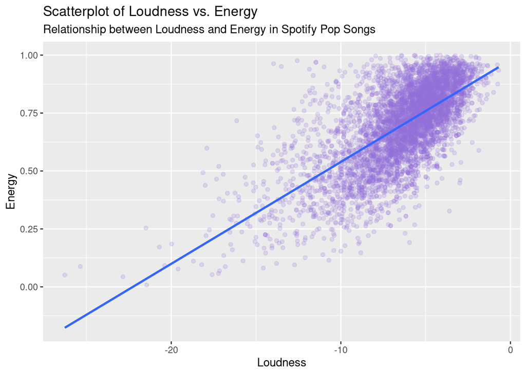

```r
pop_songs <- spotify_songs %>%
  filter(playlist_genre=="pop")

ggplot(data = pop_songs, mapping = aes(x = loudness, y = energy)) +
  geom_point(color = "mediumpurple", alpha = 0.2) +
  geom_smooth(method = "lm", se = FALSE) +
  labs(title = "Scatterplot of Loudness vs. Energy",
       subtitle = "Relationship between Loudness and Energy in Spotify Pop Songs",
       x = "Loudness",
       y = "Energy")
```

As we can see, there is a strong positive correlation between the loudness of a pop song and its energy level, meaning that on average, as the loudness/volume of a pop song increases, so does its energy level. To further corroborate this conclusion, we observed the value of different statistical quantities and compared them to our graph using the following code.

```r
pop_summary <- pop_songs %>%
  summarize(
    loudness_mean = mean(loudness, na.rm = TRUE),
    energy_mean = mean(energy, na.rm = TRUE),
    loudness_sd = sd(loudness, na.rm = TRUE),
    energy_sd = sd(energy, na.rm = TRUE)
  )
print(pop_summary)
```

```
# A tibble: 1 × 4
  loudness_mean energy_mean loudness_sd energy_sd
          <dbl>       <dbl>       <dbl>     <dbl>
1         -6.32       0.701        2.62     0.171
```

In order to learn more about the trendline created when comparing loudness in relation to energy, we ran a simple linear regression model to obtain values related to creating an equation that can calculate energy from loudness.

```r
# Linear regression model
lm_model <- lm(energy ~ loudness, data = pop_songs)

# Summary of the regression model
lm_summary <- summary(lm_model)

# Print summary statistics and regression coefficients
print(lm_summary$coef)
```

```
              Estimate   Std. Error   t value Pr(>|t|)
(Intercept) 0.97863421 0.0044434262 220.24316        0
loudness    0.04395755 0.0006498147  67.64629        0
```

## Exploratory Data Analysis 2

For our second Exploratory Data Analysis, we wanted to look at the relationship between the mode and the popularity of a track for rap songs. The variable “mode” indicates the modality (major or minor key) of a track, where 1 represents a major track and 0 is minor. The variable “track_popularity” indicates how popular a given track is from a scale of 0-100. Since we are working with one categorical variable and one numerical variable, we created a boxplot to show the relationship between these two variables. We also filtered the dataset to get only playlists under the “rap” genre.

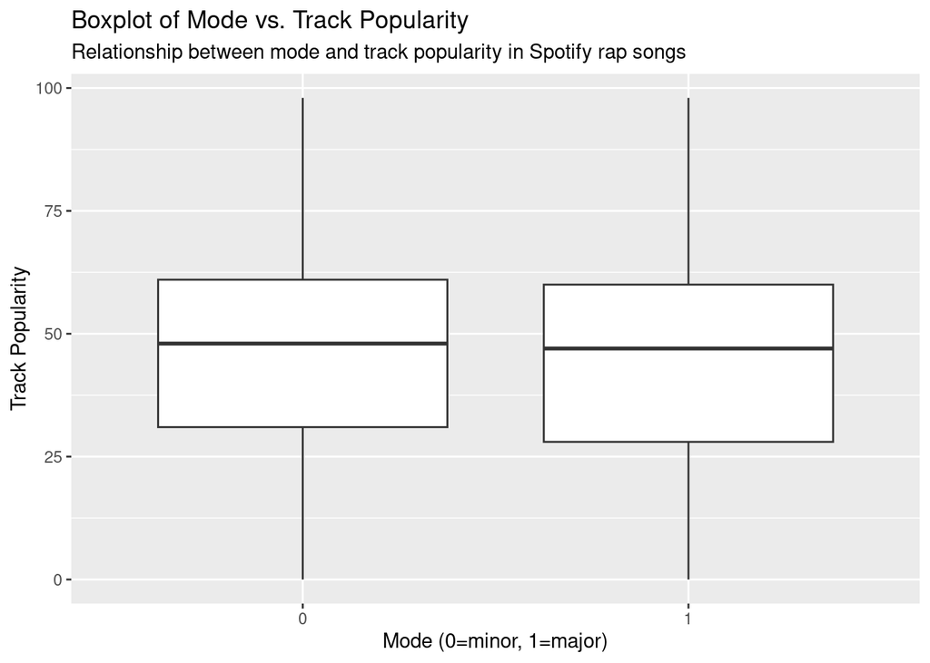

```r
rap_songs <- spotify_songs %>%
  filter(playlist_genre=="rap")

ggplot(data = rap_songs, aes(x = factor(mode), y = track_popularity)) +
  geom_boxplot() +
  labs(title = "Boxplot of Mode vs. Track Popularity",
       subtitle = "Relationship between mode and track popularity in Spotify rap songs",
       x = "Mode (0=minor, 1=major)",
       y = "Track Popularity")
```

In order to provide support for this analysis, like with the previous analysis, we used the code below to find the summary statistics of our Rap songs data.

```r
rap_summary <- rap_songs %>%
  group_by(mode) %>%
  summarize(mean = mean(track_popularity, na.rm=TRUE),
            sd = sd(track_popularity, na.rm=TRUE),
            median = median(track_popularity, na.rm=TRUE),
            iqr = IQR(track_popularity, na.rm=TRUE),
            min = min(track_popularity, na.rm=TRUE),
            max = max(track_popularity, na.rm=TRUE),
            count = n())
print(rap_summary)
```

```
# A tibble: 2 × 8
   mode  mean    sd median   iqr   min   max count
  <dbl> <dbl> <dbl>  <dbl> <dbl> <dbl> <dbl> <int>
1     0  44.1  23.2     48    30     0    98  2750
2     1  42.4  23.3     47    32     0    98  2996
```

## Regression Analysis

The regression analysis performed using the spotify_songs dataset is predicting the ‘danceability’ of a song based on the song’s recorded ‘energy’ and ‘playlist genre’. “Danceability” refers to how suitable a song is for dancing based on factors such as tempo and regularity, with 1 being the most danceable and 0 being the least. “Energy,” also measured from 0 to 1, represents the ‘activity’ of the song from elements such as timbre and loudness, with 1 representing high energy songs and 0 representing low energy songs. “Playlist genre” refers to what category a given song may fall in to, such as pop or rock.

In order to conduct this analysis without potential oversaturation from the dataset when visualizing the data initially, we filtered the genres to only be focused on how energy and danceability relate in relation to pop and rock songs before graphing the data on a scatterplot. Other considerations made were changing the transparency of each individual data point so the trendline can be seen more clearly.

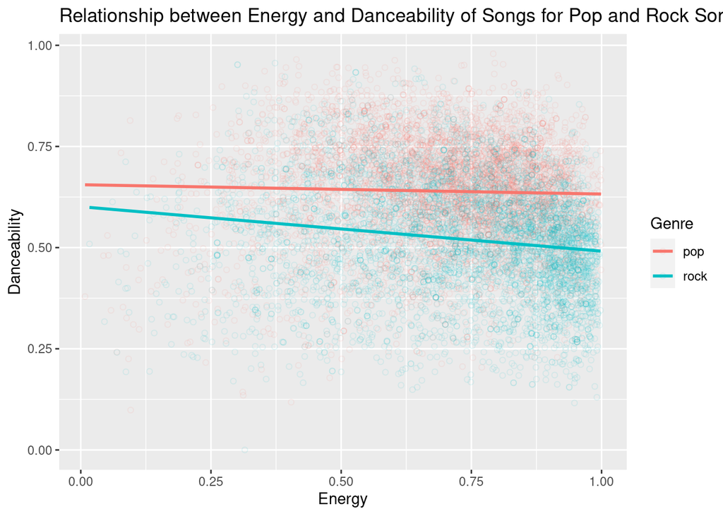

```r
poprock <- spotify_songs %>%
  filter(playlist_genre == "pop" | playlist_genre == "rock")


ggplot(poprock, aes(x = energy, y = danceability, color = playlist_genre)) +
  geom_point(shape = 1, alpha = 0.1) +
  labs(
    title = "Relationship between Energy and Danceability of Songs for Pop and Rock Songs",
    x = "Energy",
    y = "Danceability",
    color = "Genre"
    ) +
  geom_smooth(method = "lm", se = FALSE)
```

The trendlines generated from the scatterplot indicates that there does exist a type of relationship between energy and danceability, and that as energy increases in a song, danceability will typically decrease. These trendlines also indicate that the genre of a song also impacts danceability, since even though both seem to indicate that increasing energy decreases danceability, the slope of the rock trendline is considerably steeper than the slope of the pop trendline.

Since a linear relationship between the selected numeric variables ‘energy’ and ‘danceability’ is proven to exist, as well as a differing relationship based on genre, an interaction model can be used to generate an equation that can predict a song’s danceability based on its energy if the song is in the pop or rock genre, which is what the following code does.

```r
model_interaction <- lm(danceability ~ energy + playlist_genre + energy*playlist_genre, data = poprock)

print(model_interaction$coef)
```

```
              (Intercept)                    energy        playlist_genrerock
               0.65544673               -0.02303050               -0.05433657
energy:playlist_genrerock
              -0.08690499
```

The equation below shows the equation for predicting danceability without the values determined from our interaction model. Since the model gives values for “playlist_genrerock” but not “playlist_genrepop”, the equation utilizes songs in the pop genre as a baseline.

$$\widehat{danceability} = b_0 + b_1\left(energy \right) + b_2\left(1_{genrerock}\right)+ b_3\left(energy*1_{genrerock}\right)$$
“b0” represents the intercept of our equation, or what the danceability of a pop song would be given an energy of 0. “b1” represents the slope for pop songs, or by what extent a pop song’s danceability changes for every 1 unit increase in energy. “b2” is the offset of intercept for rock songs, or how much a rock song’s danceability differs from a pop song’s given an energy of 0. “b3” is the offset of slope for rock songs, or the difference in the rate of change of a rock song’s danceability per unit of energy as compared to that of a pop song.

When the energy of a pop song is 0, the danceability of that song will be expected to be 0.655 units.

For every 1 unit increase in energy, we predict danceability decreases by 0.023 units for pop songs.

When the energy of a rock song is 0, the danceability of that song will be expected to be 0.054 units less than that of a pop song.

Finally, for every 1 unit increase in energy, we predict danceability increases at a rate that is 0.087 units less than the rate of increase for a pop song, which alternatively can be stated as danceability decreasing by 0.11 units per unit increase of energy.

With this regression analysis, we were able to successfully construct a model that can predict the danceability of a song based on the song’s energy when assessing songs that fall into the ‘pop’ playlist genre or the ‘rock’ playlist genre, which is corroborated by the graphic generated above at the beginning.

## Confidence Interval

For this section, we decided to create a confidence interval of the proportion of Spotify songs from R&B playlists, as given by the statement below.

Construct a 95% confidence interval for the proportion of Spotify songs from R&B playlists that are written in the minor scale. Interpret your confidence interval in the context of the problem.

The following code gives us the data we need in order to construct our confidence level.

```r
#R code
rb_minor <- spotify_songs %>%
  filter(playlist_genre == "r&b") %>%
  count(mode)

# print data
rb_minor
```

```
# A tibble: 2 × 2
   mode     n
  <dbl> <int>
1     0  2599
2     1  2832
```

```r
prop.test(x=2599, n=5431, conf.level=0.95, correct=FALSE)
```

```
    1-sample proportions test without continuity correction

data:  2599 out of 5431, null probability 0.5
X-squared = 9.9961, df = 1, p-value = 0.001569
alternative hypothesis: true p is not equal to 0.5
95 percent confidence interval:
 0.4652834 0.4918451
sample estimates:
        p
0.4785491
```

The proportion test indicates that the 95 percent confidence interval values are 0.4652834 and 0.4918451. Based on the information above, we are 95% confident that the true proportion of songs in Spotify R&B playlists written in the minor key/scale is between 0.465 and 0.492.

## Hypothesis Test

For this section, we decided to use a hypothesis test to determine whether the average tempo of songs in a certain genre were equal to a certain value or not.

Is there sufficient evidence that Spotify songs from EDM playlists have an average tempo of 120 beats per minute? Use significance level α=0.01. Justify your hypothesis with a p-value and interpret your decision in the context of the problem.

Our null and alternative hypothesis are given below.

$$\mu_{tempo} = 120$$
$$H_A:\mu_{tempo} \ne 120$$
This code below filters our data into only including our focus, EDM songs and their tempos, and running a t.test using our filtered data.

```r
#R code
edm_tempo <- spotify_songs %>%
  select(playlist_genre, tempo) %>%
  filter(playlist_genre == "edm")

t.test(x=edm_tempo$tempo, mu=120)
```

```
    One Sample t-test

data:  edm_tempo$tempo
t = 29.265, df = 6042, p-value < 2.2e-16
alternative hypothesis: true mean is not equal to 120
95 percent confidence interval:
 125.3816 126.1544
sample estimates:
mean of x
  125.768
```

Assuming that Spotify songs from EDM playlists have an average tempo of 120 bpm, there is an almost 0% chance of observing data as extreme as ours. At an alpha = 0.01 significance level, we reject the null hypothesis since our p-value is 2.2e-16 which is less than 0.01. We have sufficient evidence to reject that the mean tempo of Spotify songs from EDM playlists is 120 bpm. Instead, we are 95% confident that the actual average tempo of songs from EDM playlists is actually higher and falls between 125.38 bpm and 126.15 bpm.

## Conclusions

Since the three of us use Spotify to listen to music on a day-to-day basis, it was very interesting to explore the relationships between different attributes of songs through this Kaggle dataset. The 32,833 songs/observations allowed us to get a broader understanding of the songs on this platform and how they relate to each other both within the same genres or with other genres.

Overall, our key findings from the Exploratory Data Analysis part were that there is a positive correlation between the loudness and energy level of pop songs on Spotify. As the loudness of a pop song increases, so does the energy level. For our second graph, we found that there is no significant difference between the popularity of rap songs in major vs. minor keys as the mean, median, standard deviation, and IQR were about the same for both modes.

For the regression analysis part, we found that different genres of songs had different danceability, but interestingly enough, songs with more energy were found to actually be less danceable in the case of songs that fell into the pop and rock genre, though rock songs were shown to generally be less danceable and have a steeper negative correlation between energy and danceability as compared to pop songs. From this, we were able to determine that a correlation existed and made a multiple regression interaction model that gave us values to use for an equation that can help determine a pop or rock song’s danceability based on its energy.

After constructing a confidence interval, we were 95% confident that the proportion of R&B songs in our Spotify dataset that were made and derived in the minor scale was approximately between 0.465 and 0.492. However, we want to discuss the potential effects of lowering and increasing our confidence interval. If we used a 90% confidence interval, the interval range would be narrower than 0.465 and 0.492, but be less reliable at capturing the true proportion of R&B songs in the minor key in the Spotify dataset. On the other hand, using a 99% confidence interval would result in an interval range larger than 0.465 and 0.492 but would increase the chance that the interval contains the true proportion of R&B songs in the minor key in our Spotify dataset.

Lastly, for the hypothesis test, we found that there was a very low chance of observing data as extreme as ours assuming that our null hypothesis that the mean tempo is 120 bpm. The p-value was also lower than our set alpha value of 0.01, indicating that it was unlikely to observe our data or data as extreme as ours under the null hypothesis. Therefore, we determined that the mean tempo of EDM playlists was not 120 bpm.

In conclusion, we were able to use this large dataset of Spotify songs to derive many findings generalizable to the larger population of Spotify songs utilizing numerous techniques, such as regression models, confidence intervals, graphics, and hypothesis tests, while using R to gain our results.